# Thesis Proposal

Predictive Modeling with Unbalanced Data

Alyssa Forber

December 2017

## Outline

Background

Problem

Objectives

Methods

Preliminary Results

Moving Forward

## Motivation

(Check out most recent manuscript from paper an citations) call it progression to opioid therapy

Opioid information

- explain issue of opioid addiction
- rare outcome
- whether or not to prescribe to patients if likely to become addicted

## Intro

The United States is facing an unprecedented opioid epidemic. According to data from the 2015 National Survey of Drug Use and Health, over 2 million people had a prescription opioid use disorder.[1]

This is particularly important in the hospital where opioids are commonly prescribed for pain.[10] Opioid receipt at hospital discharge has been shown to be associated with an increased risk of chronic opioid use.[11]

Predictive tools to identify hospitalized patients at risk for future COT may have clinical utility to improve hospital-based pain management with a focus on limiting opioid prescribing when non-opioid analgesics, or other non-pharmaceutical options, may be effective for pain control.

## Imbalanced Learning Problem

Sampling Techniques, Bagging

you might not have to get as fancy with things like bagging and just choose a better cutpoint

## The Data

Design: Denver Health retrospective analysis electronic health record (EHR) data from 2008 to 2014.

Patients: Hospitalized patients at an urban, safety-net hospital.

Definition of Chronic Opioid Therapy (COT) one year following the index hospital discharge:

> Receipt of $\geq$ 90-day supply of opioids with < 30-day gap in supply over a 180-day period or receipt of $\geq$ 10 opioid prescriptions over one year.

## Patient Population

- 27,705 patients
- Majority had incomes <185% of the Federal Poverty Level
- 70% were ethnic minorities
- 5% with COT
- Excluded Patients:
  - <15 or >85 years old
  - Those in prison, jail, or police custody
  - Those who died within one year following their index hospitalization
  - Patients with <2 healthcare visits to Denver Health three years preceding their index hospitalization
  - Undocumented persons receiving emergent hemodialysis
  - Obstetric patients

## Aims

- Accurate predicting $\rightarrow$ improving sensitivity and specificity for unbalanced outcome
- Using and comparing methods of probability cutpoints and sampling

## Methods

- Create sampled datasets
- Run model on sampled data
- Get predicted probabilites on the test data
- Optimize probability cutoff for outcome

## Model

- Roughly 2/3 temporal split of data to get train and test set
- Cross validated lasso regression
- Lasso:
  - Performs variable selection
  - Shrinks estimates to 0
- Cross validattion:
  - Find the best “tuning measure” for model selection which determines amount of shrinkage of estimates
  - Split data into k parts and then train on each of those except one you validate against
  - Then pick the tuning measure that minimizes error?

## ROC & Cutoff Probablities

ROC (with pROC package):

- ROC curve plots sensitivity vs specificity
- Top left corner is ideal
- Youden Index is the furthest upper left corner or “max”

## ROC Curve

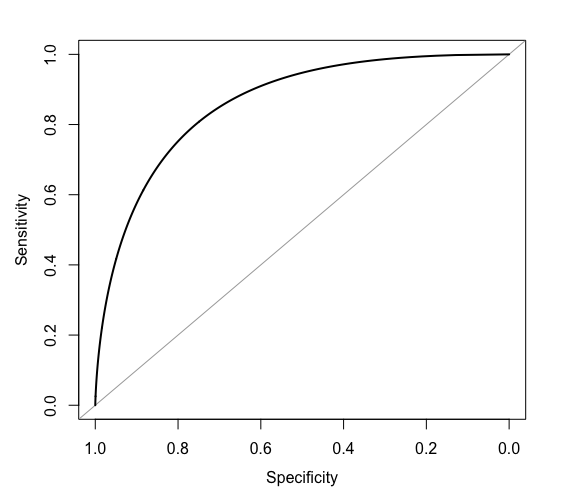

ROC Curve

## Attempt

## Confusion Matrix?

[figure not shown]

## Advantages and Disadvantages?

- Advantages:
  - Lower variance of the predicted values?
  - More accurate predictions
  - Reduces the number of predictors
- Disadvantages:
  - No interpretation of predictor coefficients
  - No standard errors out of the model
  - Biased coefficients

## First approach

No Sampling, Optimze Cut-off:

- Use original unsampled data and get predictions off the lasso model
  - Predictions return probability between 0 and 1 for each observation
- Use 0.5 standard probability cutoff
- Find “best” probability cutoff
  - Youden Index

## ROC Plot

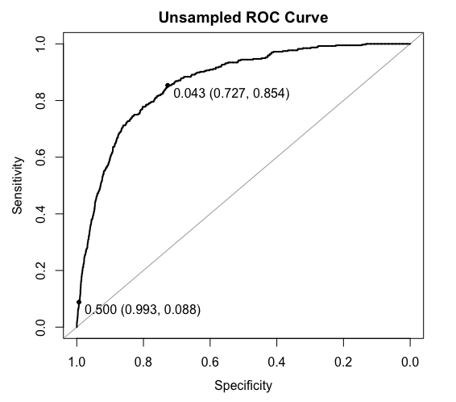

ROC for Original Data: Younden and 0.5 cutoffs

## Second Approach

Sampling:

- Create sampled data sets that are balanced
  - Down sample
  - Up sample
  - SMOTE
    - Synthetic Minority Over-sampling Technique
- Predict with Youden cutoff

## Preliminary Results

Explain prelim results (sens, spec, accuracy, AUC, npv, ppv):

Explain meaning of sens, spec, npv, and ppv???

Table of–

- non-sampled with 0.5 cutoff
- non-sample with youden cutoff
- up sample with youden cutoff
- down sample with youden cutoff
- smote sample with youden cutoff
- down sample with bagging (DONT HAVE THIS)

## Results Table

[figure not shown]

Results by Model

## Discussion of Results

- Depening on situation the clinician may like different sensitivity/specificity
- Some may want to be more conservative, others may not
  - Example: cancer patients in a significant pain

## Moving Forward

- Simulation of different percentages for rare outcomes
  - When you could run model without sampling or changing cutoffs (though sampling does allow a more parismonious model)
- Try different sampling other than defaults for each method
- Bagging (bootstrap aggregating)
- bootstrap aggregate the coefficients and get bootstrap CI (loop through getting new sample, saving coefficients, get mean and sd across 1000 boot samples) With this you may get 12 var with one stepwise and 13 with another

## More Moving Forward

- look up bagging and stepwise selection
- haven’t seen much on bagging and down sampling– look that up, if not that’ll be interesting
- maybe try lasso with cross validation (cv.lasso)
- lasso has been shown to be better at selecting a model than stepwise
- easy to save all the coefficients and bootstrap
- check to see if there’s a package to do bagging with lasso
- feed final average model with test set
- package SparseLearner? or Predict.bagging
- because when we down sample we only get one subset
- she’ll send surgical infections code

## Questions?

Questions?

## Questions for Katie

Should I show code in this?

Am I giving the talk as if for an audience of statisticians or clinicians or mixed?

What more should be expanded on?

Any figures or tables that would be helpful

show smooth spline of age and probability of COT and show it has a curve to it and why we added the quadratic age smooth.spline with 3 degrees of freedom

- Where would it make sense to include this???

## NOTES FROM 10/31

SCHEDULE!!! schedule between dec 4 and 15 send susan a note (she’ll be hardest) ask what days and times are best could send out a doodle poll then send out her availablity

accumulate other papers in endnote

## Thoughts

I think I’m confused on cv and bagging with lasso I need a better understanding of lasso first

so cv splits my sample into k subsamples and runs the model for k-1 of them and compares to the 1 left? this isn’t making sense in the scheme of already making my training and test sets with the temporal split– it seems like it doesn’t make sense to do both?

and then bagging is training many models on resampled data and then take their average to get an averaged model. this makes sense, it’s how I get my model with resampling my training data and then I fit it with the test data

SoI don’t understand cv well and I definitely don’t understand doing both together

## Thoughts cont.

I understand cv better now maybe– I use cv.glmnet to find my minimum lambda. I know that is the best. I’m not sure what it is, but it optimizes something. Then I use that min for glmnet and predict on that.

## Notes 11.14.17

Read the papers on lasso and we can go through it next time and book statistical methods chapter on shrinkage where they talk about lasso chaper 3.4 on shrinkage methods

don’t need to run glmnet after cv.glmnet, just tell predict to use the minimum lambda

look at logistic and lasso results and compare (probably not necessary to include)

See if there are any other ways to choose a threshold

Might want to come up with another methodlogical advancement

DO THIS!! email Elizabeth to see if she’s free and then send a calendar invite

DO THIS!! Just notes and what lit to look into Abstract, Background, methods, results, conclusions, acknowledgments, tables, figures, think about what’s table 1 Be good to bring to meeting with Elizabeth to give her an idea of what we’re working on!!!

under WNAR2017 talk there is a powerpoint

Just showed variables for where there is a really big split between outcomes could use those and then maybe a couple others

mention TRIPOD - mention this, about being transparent, read paper